# IE 440 - HW 6

Yusuf Ulucoban - Mustafa Comert

207402021 - 2017402141

## Data Import and Plotting

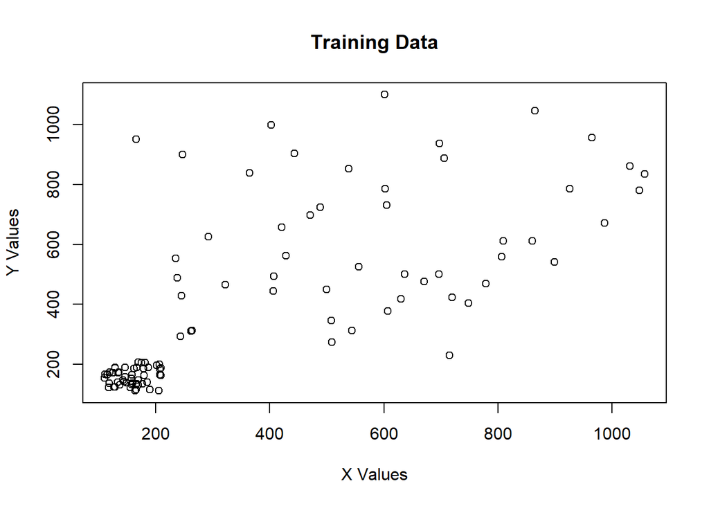

```r
training <- data.table(read.table("C:/Users/yuluc/OneDrive/Desktop/train.dat"))
plot(training, xlab = "X Values", ylab = "Y Values", main = "Training Data")
```

## Explanations

From now on, we can use following naming for the both parts of the first question.  
constant_i_j means the constant unknown for the partial derivative of i’th part according to j. Such as constant_2_a is constant value of a in the second part of the question which is polynomial regression model.  
i_variable_j_k means the unknown for the partial derivative of j’th part of the question according to k, where our parameter will be written in the side of i.  
As a result

constant_1_a + a_variable_1_a * a + b_variable_1_a * b = 0  
constant_1_b + a_variable_1_b * a + b_variable_1_b * b = 0  
equations should hold for the optimal value in the part a

## Question 1.a, Linear Regression and Calculations

As you can observe, the objective value which is summation of the errors between actual values and predictions should be minimized. The general formula could be written as “(y - b - (a * x))^2” when linear regression model is used.  
To reach optimal a and b values, partial derivatives of the objection function are needed.

```r
constant_1_a = sum(2 * training$V2 * (-training$V1))
a_variable_1_a = sum(2 * training$V1 * training$V1)
b_variable_1_a = sum(2 * training$V1)

constant_1_b = sum(-training$V2 * 2)
a_variable_1_b = sum(training$V1 * 2)
b_variable_1_b = nrow(training) * 2

constant_1_a
```

```
## [1] -39895921
```

```r
a_variable_1_a
```

```
## [1] 42526364
```

```r
b_variable_1_a
```

```
## [1] 74168.83
```

```r
constant_1_b
```

```
## [1] -77588.72
```

```r
a_variable_1_b
```

```
## [1] 74168.83
```

```r
b_variable_1_b
```

```
## [1] 200
```

Which leads us to the equations from the derivatives.

**-39895921 + 42526364 * a + 74168.83 * b = 0**  
**-77588.72 + 74168.83 * a + 200 * b = 0**

From these equations it is reached that  
**a = 0.74045571947919**  
**b = 113.3499280971**

Now let us plot the linear regression line and the all the points in the training data.

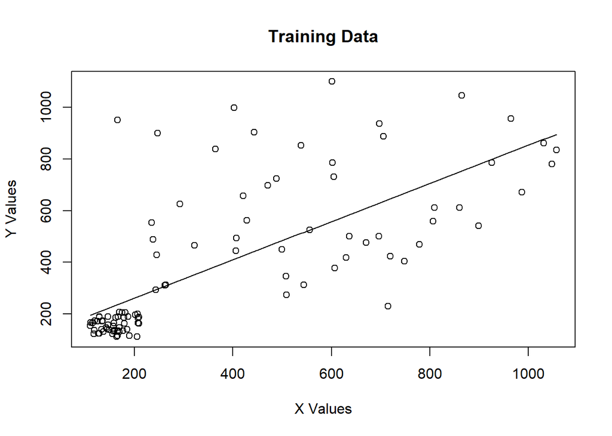

```r
plot(training, xlab = "X Values", ylab = "Y Values", main = "Training Data")
curve(0.74045571947919*x + 113.3499280971, add = TRUE)
```

```r
training1a = cbind(training, 0.74045571947919 * training[,1] + 113.3499280971)
SSE1a = (training1a[,3] - training1a[,2])^2

test1a <- data.table(read.table("C:/Users/yuluc/OneDrive/Desktop/test.dat"))
test1a = cbind(test1a, 0.74045571947919 * test1a[,1] + 113.3499280971)

TestMSE1a = sum((test1a[,3] - test1a[,2])^2) / 20

Var1a = (sum((TestMSE1a - (test1a[,3] - test1a[,2])^2)^2)) / 19
```

## Question 1.b, Polynomial Regression and Calculations

```r
constant_2_a = sum(2 * training$V2 * -(training$V1)^2)
a_variable_2_a = sum(2 * -(training$V1)^2 * -(training$V1)^2)
b_variable_2_a = sum(2 * -(training$V1) * -(training$V1)^2)
c_variable_2_a = sum(2 * -1 * -(training$V1)^2)

constant_2_b = sum(2 * training$V2 * -(training$V1))
a_variable_2_b = sum(2 * -(training$V1)^2 * -(training$V1))
b_variable_2_b = sum(2 * -(training$V1) * -(training$V1))
c_variable_2_b = sum(2 * -1 * -(training$V1))

constant_2_c = sum(2 * training$V2 * -1)
a_variable_2_c = sum(2 * -(training$V1)^2 * -1)
b_variable_2_c = sum(2 * -(training$V1) * -1)
c_variable_2_c = nrow(training) * 2

constant_2_a
```

```
## [1] -26971006785
```

```r
a_variable_2_a
```

```
## [1] 2.516379e+13
```

```r
b_variable_2_a
```

```
## [1] 3.0929e+10
```

```r
c_variable_2_a
```

```
## [1] 42526364
```

```r
constant_2_b
```

```
## [1] -39895921
```

```r
a_variable_2_b
```

```
## [1] 3.0929e+10
```

```r
b_variable_2_b
```

```
## [1] 42526364
```

```r
c_variable_2_b
```

```
## [1] 74168.83
```

```r
constant_2_c
```

```
## [1] -77588.72
```

```r
a_variable_2_c
```

```
## [1] 42526364
```

```r
b_variable_2_c
```

```
## [1] 74168.83
```

```r
c_variable_2_c
```

```
## [1] 200
```

Which leads us to the equations from the derivatives.

**-26971006785 + 2.516379e+13 * a + 3.0929e+10 * b + 42526364 * c = 0**  
**-39895921 + 3.0929e+10 * a + 42526364 * b + 74168.83 * c = 0**  
**-77588.72 + 42526364 * a + 74168.83 * b + 200 * c = 0**

From these equations it is reached that  
**a = -0.0009**  
**b = 1.6593**  
**c = -33.7914**

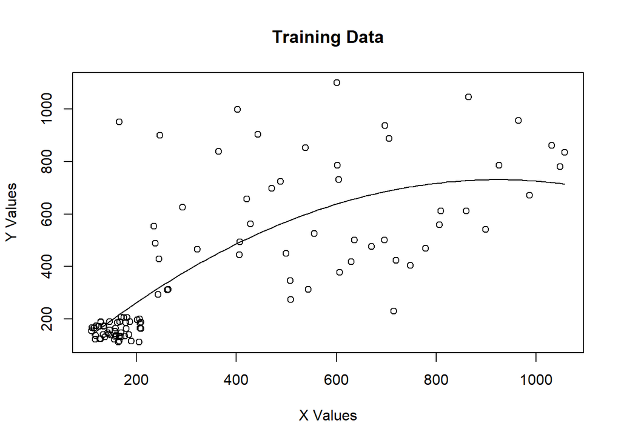

```r
plot(training, xlab = "X Values", ylab = "Y Values", main = "Training Data")
curve(-0.0009 * x^2 + 1.6593 * x + -33.7914, add = TRUE)
```

```r
training1b = cbind(training, -0.0009 * training[,1]^2 + 1.6593 * training[,1] + -33.7914)
SSE1b = (training1b[,3] - training1b[,2])^2

test1b <- data.table(read.table("C:/Users/yuluc/OneDrive/Desktop/test.dat"))
test1b = cbind(test1b, -0.0009 * test1b[,1]^2 + 1.6593 * test1b[,1] + -33.7914)

TestMSE1b = sum((test1b[,3] - test1b[,2])^2) / 20

Var1b = (sum((TestMSE1b - (test1b[,3] - test1b[,2])^2)^2)) / 19
```

## Question 2.a, BackPropagation Algorithm and Hidden Units for part A

Firstly, lets try to create our random wij and Wjk values with runif function.

```r
training <- data.table(read.table("C:/Users/yuluc/OneDrive/Desktop/train.dat"))
test <- data.table(read.table("C:/Users/yuluc/OneDrive/Desktop/test.dat"))

X <- matrix(training$V1)
y <- matrix(training$V2)

neural_network <- list(
  input = X,
  weights1 = matrix(runif(3), ncol = 3),
  weights2 = matrix(runif(3), ncol = 1),
  y = y,
  output = matrix(
    rep(0, times = 100),
    ncol = 1
  )
)
```

Now, the sigmoid function and the derivative of the sigmoid function should be defined.

```r
sigmoid <- function(x) {
  1 / (1 + exp(-x))
}

sigmoid_derivative <- function(x) {
  sigmoid(x) * (1 - sigmoid(x))
}
```

Now, lets try to create backpropagation function in order to find weights.

```r
alpha <- c(0.5)
eta <- 0.9
error <- 0.001
k = 1
while(alpha[k] > error){
  neural_network$hidden <- sigmoid(neural_network$input %*% neural_network$weights1)
  neural_network$output <- sigmoid(neural_network$hidden %*% neural_network$weights2)

  d_weights2 <- (t(neural_network$hidden) %*% (2*(neural_network$y - neural_network$output) * sigmoid_derivative(neural_network$output)))
  d_weights1 <- ( 2 * (neural_network$y - neural_network$output) * sigmoid_derivative(neural_network$output)) %*% t(neural_network$weights2)
  d_weights1 <- d_weights1 * sigmoid_derivative(neural_network$hidden)
  d_weights1 <- t(neural_network$input) %*% d_weights1

  neural_network$weights1 <- neural_network$weights1 + d_weights1
  neural_network$weights2 <- neural_network$weights2 + d_weights2
  alpha[k+1] = eta * alpha[k]
  k = k+1
}
```

Lets check, weights and values.

```r
data.frame(
neural_network$weights1
)
```

```
##             X1           X2           X3
## 1 4.022239e+13 4.022242e+13 4.022246e+13
```

```r
data.frame(
neural_network$weights2
)
```

```
##   neural_network.weights2
## 1                899363.7
## 2                899364.1
## 3                899364.6
```

It seems that our algorithm managed to find some weights for 3 different hidden units where weights1 represents from input to 3 hidden units and weights2 represents from 3 hidden units to one output unit.

```r
data.frame(
  "Predicted" = neural_network$output,
  "Actual" = y
)
```

```
##     Predicted    Actual
## 1           1  185.7992
## 2           1  111.4364
## 3           1  134.8142
## 4           1  189.2571
## 5           1  183.1754
## 6           1  165.4412
## 7           1  164.2997
## 8           1  131.8487
## 9           1  172.6905
## 10          1  147.0300
## 11          1  134.1375
## 12          1  153.9033
## 13          1  140.7703
## 14          1  187.5932
```

[output cut: 86 more lines]

However, the predictions are wrong. We did our best to find the wrong part in the code but we were not be succesful.  
Now, MSE should be calculated.

```r
SSE2a <- sum((neural_network$output - y)^2)
```

Next step is to define hidden units function. Although our predictions are wrong, an algorithm that is written will be correct when the prediction mechanism is confirmed.  
The algorithm below is written as to find optimal number of hidden units but does not work properly because of the wrong calculations of predictions and errors. we believe that hidden units algorithm is true.

```r
X <- matrix(test$V1)
y <- matrix(test$V2)

neural_network <- list(
  input = X,
  weights1 = neural_network$weights1,
  weights2 = neural_network$weights2,
  y = y,
  output = matrix(
    rep(0, times = 20),
    ncol = 1
  )
)
neural_network$hidden <- sigmoid(neural_network$input %*% neural_network$weights1)
neural_network$output <- sigmoid(neural_network$hidden %*% neural_network$weights2)
E = c(mean((y - neural_network$output)^2))
k = 1
J <- 4


repeat{
neural_network <- list(
  input = X,
  weights1 = matrix(runif(J), ncol = J),
  weights2 = matrix(runif(J), ncol = 1),
  y = y,
  output = matrix(
    rep(0, times = 20),
    ncol = 1
  )
)

neural_network$hidden <- sigmoid(neural_network$input %*% neural_network$weights1)
neural_network$output <- sigmoid(neural_network$hidden %*% neural_network$weights2)
k = k+1
J = J+1
E[k] = mean((y - neural_network$output)^2)
if(E[k] >= E[k-1]){break
  }
}

J-1
```

```
## [1] 4
```

```r
E
```

```
## [1] 278236.7 278347.7
```

```r
TestMSE2a <- sum((neural_network$output - y)^2) / 20

Var2a = (sum((TestMSE2a - (neural_network$output - y)^2)^2)) / 19
```

## Question 2.b, BackPropagation Algorithm and Hidden Units for part B

Everything in the 2.b is the same as 2.a although there are one difference.  
In the question 2.b, we have two input points one is x and the other one is x^2, which leads us to change our weight matrices nrows and ncols.  
Since there are two inputs to 3 hidden units in the first step, 2x3 weights1 matrix and again 3 hidden units to one output, 3x1 weights matrix will be satisfying.  
And again, since our predictions and consequently errors are not correct, the hidden unit function gives us the wrong answer until we correct the predictions.

```r
training <- data.table(read.table("C:/Users/yuluc/OneDrive/Desktop/train.dat"))
test <- data.table(read.table("C:/Users/yuluc/OneDrive/Desktop/test.dat"))

X <- matrix(rbind(training$V1, (training$V1)^2), ncol = 2)
y <- matrix(training$V2)

neural_network <- list(
  input = X,
  weights1 = matrix(runif(6), ncol = 3),
  weights2 = matrix(runif(3), ncol = 1),
  y = y,
  output = matrix(
    rep(0, times = 100),
    ncol = 1
  )
)



alpha <- c(0.5)
eta <- 0.9
error <- 0.001
k = 1
while(alpha[k] > error){
  neural_network$hidden <- sigmoid(neural_network$input %*% neural_network$weights1)
  neural_network$output <- sigmoid(neural_network$hidden %*% neural_network$weights2)

  d_weights2 <- (t(neural_network$hidden) %*% (2*(neural_network$y - neural_network$output) * sigmoid_derivative(neural_network$output)))
  d_weights1 <- ( 2 * (neural_network$y - neural_network$output) * sigmoid_derivative(neural_network$output)) %*% t(neural_network$weights2)
  d_weights1 <- d_weights1 * sigmoid_derivative(neural_network$hidden)
  d_weights1 <- t(neural_network$input) %*% d_weights1

  neural_network$weights1 <- neural_network$weights1 + d_weights1
  neural_network$weights2 <- neural_network$weights2 + d_weights2
  alpha[k+1] = eta * alpha[k]
  k = k+1
}


data.frame(
neural_network$weights1
)
```

```
##             X1           X2           X3
## 1 9.918604e+14 9.918589e+14 9.918594e+14
## 2 1.427322e+16 1.427320e+16 1.427321e+16
```

```r
data.frame(
neural_network$weights2
)
```

```
##   neural_network.weights2
## 1                899281.7
## 2                899281.0
## 3                899281.2
```

```r
data.frame(
  "Predicted" = neural_network$output,
  "Actual" = y
)
```

```
##     Predicted    Actual
## 1           1  185.7992
## 2           1  111.4364
## 3           1  134.8142
## 4           1  189.2571
## 5           1  183.1754
## 6           1  165.4412
## 7           1  164.2997
## 8           1  131.8487
## 9           1  172.6905
## 10          1  147.0300
## 11          1  134.1375
## 12          1  153.9033
## 13          1  140.7703
## 14          1  187.5932
```

[output cut: 86 more lines]

```r
SSE2b <- sum((neural_network$output - y)^2)
```

```r
X <- matrix(rbind(test$V1, (test$V1)^2), ncol = 2)
y <- matrix(test$V2)

neural_network <- list(
  input = X,
  weights1 = neural_network$weights1,
  weights2 = neural_network$weights2,
  y = y,
  output = matrix(
    rep(0, times = 20),
    ncol = 1
  )
)
neural_network$hidden <- sigmoid(neural_network$input %*% neural_network$weights1)
neural_network$output <- sigmoid(neural_network$hidden %*% neural_network$weights2)
E2 = c(mean((y - neural_network$output)^2))
k = 1
J <- 4


repeat{
neural_network <- list(
  input = X,
  weights1 = matrix(runif(2*J), ncol = J),
  weights2 = matrix(runif(J), ncol = 1),
  y = y,
  output = matrix(
    rep(0, times = 20),
    ncol = 1
  )
)

neural_network$hidden <- sigmoid(neural_network$input %*% neural_network$weights1)
neural_network$output <- sigmoid(neural_network$hidden %*% neural_network$weights2)
k = k+1
J = J+1
E2[k] = mean((y - neural_network$output)^2)
if(E2[k] >= E2[k-1]){break
  }
}

J-1
```

```
## [1] 4
```

```r
E2
```

```
## [1] 278236.7 278296.9
```

```r
TestMSE2b <- sum((neural_network$output - y)^2) / 20

Var2b = (sum((TestMSE2b - (neural_network$output - y)^2)^2)) / 19
```

## Results

Although the algorithm finds some values for Wij and wjk to as their weights, there is aproblem that causes to prediction to become 1 for training set. That situation makes our predictions for test data to become wrong.  
That is the reason why all of the SSE and MSE’s are not correct for the second question. However, we believe that the solution for the first question is correct.

```r
df <- data.frame(matrix(ncol = 4, nrow = 0))
x <- c("Method", "Training SSE", "Test MSE", "s^2 for Test MSE")
colnames(df) <- x

df[1,1] = "1a"
df[2,1] = "1b"
df[3,1] = "2a"
df[4,1] = "2b"

df[1,2] = SSE1a
df[2,2] = SSE1b
df[3,2] = SSE2a
df[4,2] = SSE2b

df[1,3] = TestMSE1a
df[2,3] = TestMSE1b
df[3,3] = TestMSE2a
df[4,3] = TestMSE2b

df[1,4] = Var1a
df[2,4] = Var1b
df[3,4] = Var2a
df[4,4] = Var2b


df
```

```
##   Method Training SSE  Test MSE s^2 for Test MSE
## 1     1a 2.247097e+03  50246.69      10689611372
## 2     1b 6.456594e+02  42735.57       8367792166
## 3     2a 2.292607e+07 278347.70     138513318468
## 4     2b 2.292607e+07 278296.95     138485583383
```